# Example: downloading data from JSOC

Reference http://docs.sunpy.org/en/stable/guide/acquiring_data/jsoc.html

```python
%load_ext autoreload
%autoreload 2

import astropy.units as u

from sunpy.net import Fido, attrs

# Suppress warnings of pandas, astropy
import warnings
warnings.simplefilter("ignore", category=FutureWarning)
from astropy.utils.exceptions import AstropyDeprecationWarning
warnings.simplefilter("ignore", category=AstropyDeprecationWarning)
```

To be clear, here we use

```
from sunpy.net import Fido, attrs
```

instead of examples in http://docs.sunpy.org/en/stable/guide/acquiring_data/jsoc.html

```
from sunpy.net import Fido, attrs as a
```

## Getting information

`drms` - Python module for accessing HMI, AIA and MDI data

- https://github.com/kbg/drms
- http://drms.readthedocs.io/en/stable/tutorial.html

### Series

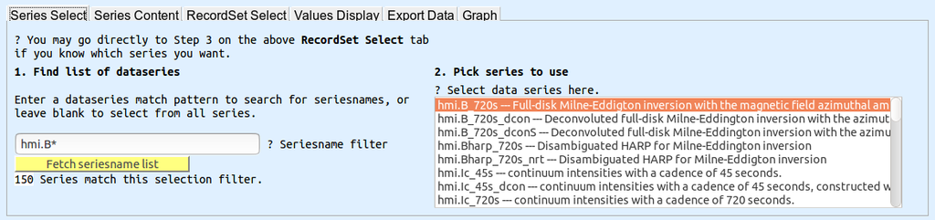

Import the `drms` module and create an instance of the `drms.Client` class:

```python
import drms
c = drms.Client()
```

List available `Series`:

```python
c.series(r'aia\..*')  # regex, case-insensitive
```

```
['aia.flatfield',
 'aia.lev1',
 'aia.lev1_euv_12s',
 'aia.lev1_uv_24s',
 'aia.lev1_vis_1h',
 'aia.master_pointing3h',
 'aia.response',
 'aia.temperature_summary_300s']
```

```python
c.series(r'hmi\.b.*')  # regex, case-insensitive
```

```
['hmi.B_720s',
 'hmi.B_720s_dcon',
 'hmi.B_720s_dconS',
 'hmi.Bharp_720s',
 'hmi.Bharp_720s_nrt',
 'hmi.b_135s',
 'hmi.b_720s_e15w1332_cea',
 'hmi.b_720s_e15w1332_cutout',
 'hmi.b_synoptic',
 'hmi.b_synoptic_small',
 'hmi.bmap_lowres_latlon_720s']
```

### PrimeKeys

Find out the `PrimeKeys` supported in any `Series`:

```python
c.pkeys('aia.lev1_euv_12s')  # case-insensitive
```

```
['T_REC', 'WAVELNTH']
```

```python
c.pkeys('hmi.B_720s')  # case-insensitive
```

```
['T_REC']
```

### Segments

Find out the `Segments` supported in any `Series`:

- 'aia.lev1_euv_12s'

```python
si = c.info('aia.lev1_euv_12s')
si.segments
```

| name | type | units | protocol | dims | note |
| --- | --- | --- | --- | --- | --- |
| image | int | None | link via lev1 | None | AIA level 1 image |
| spikes | int | None | link via lev1 | None | Cosmic ray information |

```python
si.segments.index.values  # To a `ndarray`
```

```
array(['image', 'spikes'], dtype=object)
```

```python
si.segments.index[0]  # Use slice to pick a value
```

```
'image'
```

- 'hmi.b_720s'

```python
si = c.info('hmi.b_720s')
si.segments[:4]  # Use slice to pick rows
```

| name | type | units | protocol | dims | note |
| --- | --- | --- | --- | --- | --- |
| inclination | int | None | link via MDATA | None | Inclination |
| azimuth | int | None | link via MDATA | None | Azimuth before disambiguation |
| disambig | char |  | fits | 4096x4096 | Flag for 180 degree change in azimuth |
| field | int | None | link via MDATA | None | Field Strength |

## Basic usage

See http://docs.sunpy.org/en/stable/guide/acquiring_data/jsoc.html

> There are two ways of downloading JSOC data.
> - One way is using Sunpy’s unified search interface, known as`Fido`.  
>   `Fido` supplies a single, easy and consistent way to to obtain most forms of solar physics data.
> - An alternative way to fetch data from JSOC is by using the underlying `JSOCClient`.  
>   This option can be preferred when the complex searches are to be made, or when you need to separate the staging and downloading steps, which is not supported by `Fido`.

### Fido

#### Searching for data

```python
response = Fido.search(
    attrs.jsoc.Time('2014-01-01T00:00:00', '2014-01-01T00:00:30'),
    attrs.jsoc.Notify('lydiazly@nju.edu.cn'),
    attrs.jsoc.Series('aia.lev1_euv_12s'),
    attrs.jsoc.Wavelength(304 * u.AA) | attrs.jsoc.Wavelength(171 * u.AA)
)
response
```

Results from 2 Providers:3 Results from the JSOCClient:*Table length=3*

| T_REC str20 | TELESCOP str7 | INSTRUME str5 | WAVELNTH int64 | CAR_ROT int64 |
| --- | --- | --- | --- | --- |
| 2014-01-01T00:00:01Z | SDO/AIA | AIA_4 | 304 | 2145 |
| 2014-01-01T00:00:13Z | SDO/AIA | AIA_4 | 304 | 2145 |
| 2014-01-01T00:00:25Z | SDO/AIA | AIA_4 | 304 | 2145 |

3 Results from the JSOCClient:*Table length=3*

| T_REC str20 | TELESCOP str7 | INSTRUME str5 | WAVELNTH int64 | CAR_ROT int64 |
| --- | --- | --- | --- | --- |
| 2014-01-01T00:00:01Z | SDO/AIA | AIA_3 | 171 | 2145 |
| 2014-01-01T00:00:13Z | SDO/AIA | AIA_3 | 171 | 2145 |
| 2014-01-01T00:00:25Z | SDO/AIA | AIA_3 | 171 | 2145 |

```python
type(response)
```

```
sunpy.net.fido_factory.UnifiedResponse
```

#### Indexing

- First index: client (still necessary even if results are only found for a single client)
- Second index: rows (must be **iterable**, different from [Example: downloading data using Fido])

```python
response[1]
```

Results from 1 Provider:3 Results from the JSOCClient:*Table length=3*

| T_REC str20 | TELESCOP str7 | INSTRUME str5 | WAVELNTH int64 | CAR_ROT int64 |
| --- | --- | --- | --- | --- |
| 2014-01-01T00:00:01Z | SDO/AIA | AIA_3 | 171 | 2145 |
| 2014-01-01T00:00:13Z | SDO/AIA | AIA_3 | 171 | 2145 |
| 2014-01-01T00:00:25Z | SDO/AIA | AIA_3 | 171 | 2145 |

```python
response[1, ::2]
```

Results from 1 Provider:2 Results from the JSOCClient:*Table length=2*

| T_REC str20 | TELESCOP str7 | INSTRUME str5 | WAVELNTH int64 | CAR_ROT int64 |
| --- | --- | --- | --- | --- |
| 2014-01-01T00:00:01Z | SDO/AIA | AIA_3 | 171 | 2145 |
| 2014-01-01T00:00:25Z | SDO/AIA | AIA_3 | 171 | 2145 |

```python
response[0, [2]]  # Not `response[0, 2]` !
```

Results from 1 Provider:1 Results from the JSOCClient:*Table length=1*

| T_REC str20 | TELESCOP str7 | INSTRUME str5 | WAVELNTH int64 | CAR_ROT int64 |
| --- | --- | --- | --- | --- |
| 2014-01-01T00:00:25Z | SDO/AIA | AIA_4 | 304 | 2145 |

#### Downloading data

Download the entire results:

```python
res = Fido.fetch(response, path='./data')  # Will output a progress bar by default
```

### JSOCClient

> The JSOC stages data before you can download it, so a JSOC query is a **three** stage process.
> 1. **`search`**: query the JSOC for records and a table of these records is returned.  
>    The result is `UnifiedResponse` for `Fido` while `JSOCResponse` for `JSOCClient`
> - **`request_data`**: request these records to be staged for download.
> - **`get_request`**: download.

> (`Fido` combines the stages into 2, `search` and `fetch`.)

#### Searching for data

```python
from sunpy.net import jsoc
client = jsoc.JSOCClient()
```

```python
response = client.search(
    attrs.jsoc.Time('2014-01-01T00:00:00', '2014-01-01T00:00:20'),
    attrs.jsoc.Notify('lydiazly@nju.edu.cn'),
    attrs.jsoc.Series('aia.lev1_euv_12s'),
    attrs.jsoc.Wavelength(304 * u.AA) | attrs.jsoc.Wavelength(171 * u.AA)
)
response
```

*Table length=4*

| T_REC str20 | TELESCOP str7 | INSTRUME str5 | WAVELNTH int64 | CAR_ROT int64 |
| --- | --- | --- | --- | --- |
| 2014-01-01T00:00:01Z | SDO/AIA | AIA_4 | 304 | 2145 |
| 2014-01-01T00:00:13Z | SDO/AIA | AIA_4 | 304 | 2145 |
| 2014-01-01T00:00:01Z | SDO/AIA | AIA_3 | 171 | 2145 |
| 2014-01-01T00:00:13Z | SDO/AIA | AIA_3 | 171 | 2145 |

Note here we get a single table.

```python
type(response)
```

```
sunpy.net.jsoc.jsoc.JSOCResponse
```

#### Indexing

An integer get a `Row`:

```python
response[2]
```

*Row index=2*

| T_REC str20 | TELESCOP str7 | INSTRUME str5 | WAVELNTH int64 | CAR_ROT int64 |
| --- | --- | --- | --- | --- |
| 2014-01-01T00:00:01Z | SDO/AIA | AIA_3 | 171 | 2145 |

A **iterable** get a `Table`:

```python
response[[2]]
```

*Table length=1*

| T_REC str20 | TELESCOP str7 | INSTRUME str5 | WAVELNTH int64 | CAR_ROT int64 |
| --- | --- | --- | --- | --- |
| 2014-01-01T00:00:01Z | SDO/AIA | AIA_3 | 171 | 2145 |

Convert a `Row` to a `Table`:

```python
from astropy.table.table import Table
Table(response[2].table)
```

*Table length=1*

| T_REC str20 | TELESCOP str7 | INSTRUME str5 | WAVELNTH int64 | CAR_ROT int64 |
| --- | --- | --- | --- | --- |
| 2014-01-01T00:00:01Z | SDO/AIA | AIA_3 | 171 | 2145 |

Other examples:

```python
response[::2]
```

*Table length=2*

| T_REC str20 | TELESCOP str7 | INSTRUME str5 | WAVELNTH int64 | CAR_ROT int64 |
| --- | --- | --- | --- | --- |
| 2014-01-01T00:00:01Z | SDO/AIA | AIA_4 | 304 | 2145 |
| 2014-01-01T00:00:01Z | SDO/AIA | AIA_3 | 171 | 2145 |

```python
response[:2]
```

*Table length=2*

| T_REC str20 | TELESCOP str7 | INSTRUME str5 | WAVELNTH int64 | CAR_ROT int64 |
| --- | --- | --- | --- | --- |
| 2014-01-01T00:00:01Z | SDO/AIA | AIA_4 | 304 | 2145 |
| 2014-01-01T00:00:13Z | SDO/AIA | AIA_4 | 304 | 2145 |

```python
response[[0, 2]]
```

*Table length=2*

| T_REC str20 | TELESCOP str7 | INSTRUME str5 | WAVELNTH int64 | CAR_ROT int64 |
| --- | --- | --- | --- | --- |
| 2014-01-01T00:00:01Z | SDO/AIA | AIA_4 | 304 | 2145 |
| 2014-01-01T00:00:01Z | SDO/AIA | AIA_3 | 171 | 2145 |

#### Downloading data

Download the entire results:

```python
res = client.fetch(response, path='./data')
```

```
Export request pending. [id="JSOC_20180710_1151", status=2]
Waiting for 0 seconds...
Export request pending. [id="JSOC_20180710_1151", status=1]
Waiting for 5 seconds...
4 URLs found for download. Full request totalling 17MB
Export request pending. [id="JSOC_20180710_1152", status=2]
Waiting for 0 seconds...
4 URLs found for download. Full request totalling 24MB
```

```python
res.wait()  # Show the progress bar & wait to finish downloading.
```

Or separate out the staging to `request_data` & `get_request`:

```python
requests = client.request_data(response)
```

```python
requests.id
```

```
'JSOC_20180708_435'
```

```python
requests.status
```

```
0
```

```python
res = client.get_request(requests, path='./data')
```

```python
res.wait()
```

So far, the best way to download a subset of the results is to **make a query again**.

Or use **`JSOCClient`** (and a custom function) instead of **`Fido`** to search for data.

See details below:

If slice the result as `response[2]`, everything is OK except `query_args` is lost.

```python
response.query_args
```

[output not shown]

```python
response[2].query_args
```

[output not shown]

This will cause an error in `fetch`.

## Constructing complex queries

### Time

http://docs.sunpy.org/en/stable/guide/acquiring_data/jsoc.html

> Start and end times for the query (any date/time format understood by SunPy’s `parse_time` function can be used to specify dates and time). **The Time attribute takes UTC time, as default.**  
> If you need to pass a Time in some other time scale, such as TAI, pass an Astropy Time object

See http://docs.sunpy.org/en/stable/guide/time.html#parse-time

```python
from sunpy.time import parse_time, is_time, is_time_in_given_format
```

```python
is_time('2014-01-01T00:00:00')
```

```
True
```

```python
is_time_in_given_format('2014-01-01T00:00:00Z', "%Y-%m-%dT%H:%M:%SZ")
```

```
True
```

```python
parse_time('2015.08.27_06:00:00_TAI')
```

```
datetime.datetime(2015, 8, 27, 6, 0)
```

```python
parse_time('2014-01-01T00:00:00Z')
```

```
datetime.datetime(2014, 1, 1, 0, 0)
```

If `sunpy.time` doesn't inlude this format: "%Y-%m-%dT%H:%M:%SZ", use a bash script to add it:

```python
!sunpy-add-time-fmt
```

```
Added this format to
/home/lydia/miniconda3/lib/python3.6/site-packages/sunpy/time/time.py:

    "%Y-%m-%dT%H:%M:%SZ",      # Example 2007-05-04T21:08:12Z

=== Done!(sunpy-add-time-fmt) ===
```

```python
parse_time('2014-01-01T00:00:00Z')
```

```
datetime.datetime(2014, 1, 1, 0, 0)
```

For convenience, use a custom function to pass a time string in 'TAI' scale:

```python
from usr_sunpy import tai
```

```python
tai('2014-01-01T00:00:00')  # Returns a single object
```

```
<Time object: scale='tai' format='datetime' value=2014-01-01 00:00:00>
```

```python
tai('2015.08.27_06:00:00_TAI')
```

```
<Time object: scale='tai' format='datetime' value=2015-08-27 06:00:00>
```

```python
tai('2015.08.27_06:00:00_TAI', '2015.08.27_06:01:00_TAI')  # Returns a list
```

```
[<Time object: scale='tai' format='datetime' value=2015-08-27 06:00:00>,
 <Time object: scale='tai' format='datetime' value=2015-08-27 06:01:00>]
```

### Searching for data

JSOC http://jsoc.stanford.edu/ajax/lookdata.html

- To make a request, [register your email first](http://jsoc.stanford.edu/ajax/register_email.html) :

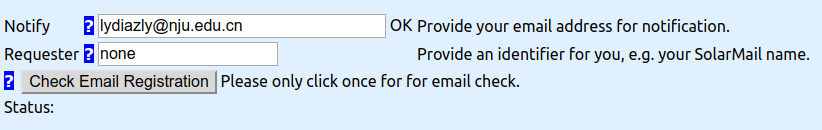

Example of [online JSOC interface](http://jsoc.stanford.edu/ajax/lookdata.html) :

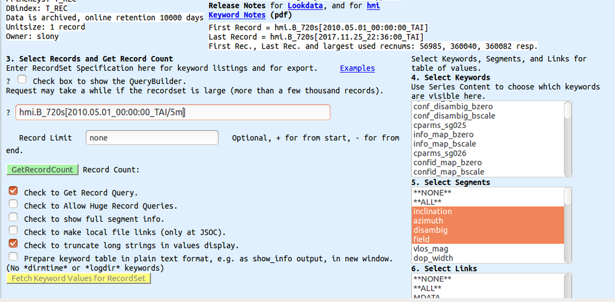

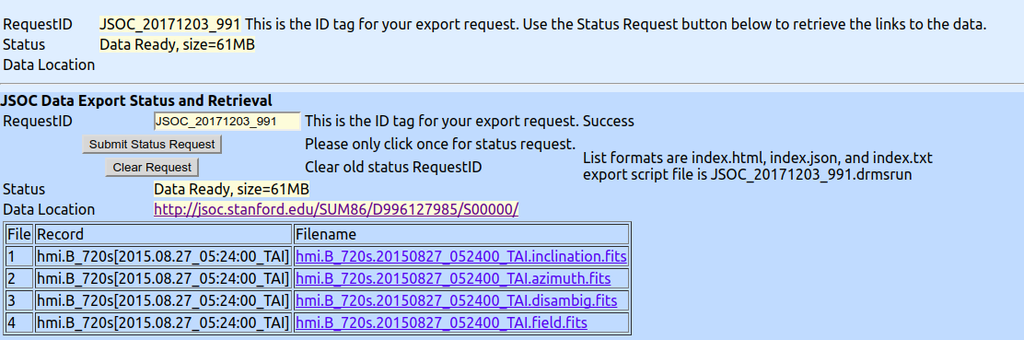

Use

```
attrs.jsoc.Segment('...') &  attrs.jsoc.<attr>('...') ...
```

```
attrs.jsoc.Segment('...') |  attrs.jsoc.<attr>('...') ...
```

or

```
from sunpy.net.attr import AttrAnd, AttrOr
```

```
AttrAnd(list(map(attrs.jsoc.<attr>, <list>)))
```

```
AttrOr(list(map(attrs.jsoc.<attr>, <list>)))
```

to pass multiple attributes.

Note:

> The attributes which support **`&`** are **`PrimeKey`** and **`Segment`**. Using **`&`** with any other attributes will throw an error.
- Specify attributes:

e.g.

```python
trange = tai('2015-08-27T05:00:00', '2015-08-27T06:00:00')

segments = ['inclination', 'azimuth', 'disambig', 'field']

series = 'hmi.B_720s'  # 'hmi.b_720s' is OK

interval = 10 * u.min  # every 10 min.

email = 'lydiazly@nju.edu.cn'
```

- Making a query:

```python
from sunpy.net.attr import AttrAnd, AttrOr
```

```python
response = Fido.search(
    attrs.jsoc.Time(*trange),
    attrs.jsoc.Series(series),
    attrs.jsoc.Notify(email),
    attrs.Sample(interval),
    AttrAnd(list(map(attrs.jsoc.Segment, segments)))
    # i.e. attrs.jsoc.Segment('...') &  attrs.jsoc.Segment('...') ...
)
response
```

Results from 1 Provider:6 Results from the JSOCClient:*Table length=6*

| T_REC str23 | TELESCOP str7 | INSTRUME str9 | WAVELNTH float64 | CAR_ROT int64 |
| --- | --- | --- | --- | --- |
| 2015.08.27_05:00:00_TAI | SDO/HMI | HMI_SIDE1 | 6173.0 | 2167 |
| 2015.08.27_05:12:00_TAI | SDO/HMI | HMI_SIDE1 | 6173.0 | 2167 |
| 2015.08.27_05:24:00_TAI | SDO/HMI | HMI_SIDE1 | 6173.0 | 2167 |
| 2015.08.27_05:36:00_TAI | SDO/HMI | HMI_SIDE1 | 6173.0 | 2167 |
| 2015.08.27_05:48:00_TAI | SDO/HMI | HMI_SIDE1 | 6173.0 | 2167 |
| 2015.08.27_06:00:00_TAI | SDO/HMI | HMI_SIDE1 | 6173.0 | 2167 |